# Show me the ROI: Classification Metrics for Business

## Best bang for the buck

After building a Machine Learning model to predict the likelihood of an event to occur e.g. likelihood of a machine to fail, likelihood of a customer to churn, likelihood of a patient to have a medical event, likelihood of a member to respond to outreach etc. the next step typically is to design a plan for taking actions based on the predictions from the model. Often the question that comes up is what is the least number of cases (customers, patients, machines etc.) I can target to get optimal results. The answer to this question can be found in the capture rate analysis, the cumulative gain and lift chart. These metrics are related to each other and are used interchangeably but all answer the same business question of how to get the best bang for the buck.

```python
# python utility function to calculate metrics
def metrics_roi(actual,pred_prob):
    '''
    Purpose: Function to calculate capture rate, cumulative gain and lift
    Inputs : Accepts the actual classes and predicted probabilities as series
    Output : A dataframe
    '''
    df_model = pd.DataFrame({'actual':actual, 'pred_prob':pred_prob})
    Total_size = df_model.shape[0]
    # bin data into deciles (10 equal sized* groups)
    df_model['decile'] = pd.qcut(df_model['pred_prob'].rank(method='first'),10, labels=False)
    # get group size in each decile ~ Total_size/10*
    group_size = df_model.groupby('decile').size().tolist()
    df_group_size = df_model.groupby('decile').size().reset_index()
    df_group_size.columns = ['decile', 'group_size']
    df_roi = df_model.groupby(['decile','actual']).size().reset_index()
    df_roi.columns = ['decile','actual','count_actual_1s']
    # keep rows with intended outcomes (actual==1)
    df_roi = df_roi.loc[df_roi['actual']==1,]
    # drop 'actual' column
    df_roi.drop('actual', axis=1, inplace=True)
    # add group_size column
    df_roi = pd.merge(df_roi, df_group_size, on = ['decile'], how = 'left')
    # denote the top decile (group with highest predicted probs) as decile = 1
    df_roi['decile'] = 10 - df_roi['decile']
    df_roi = df_roi.sort_values('decile',ascending=True)
    # calculate capture rate aka response rate for each decile
    df_roi['capture_rate'] = df_roi['count_actual_1s']/df_roi['group_size']
    df_roi['cum_count_actual_1s'] = df_roi['count_actual_1s'].cumsum()
    # count of all positive events (actual 1s) in the data
    Total_1s = df_model.loc[(df_model['actual']==1) ,].shape[0]
    # Cumulative Gain
    df_roi['cum_gain'] = df_roi['cum_count_actual_1s']/Total_1s
    df_roi['cum_gain'] = round(df_roi['cum_gain'],3)
    df_roi['baseline'] = df_roi['decile']* 10
    # Lift
    df_roi['lift'] = df_roi['cum_gain']*100 / df_roi['baseline']
    df_roi['lift'] = round(df_roi['lift'],3)
    return df_roi
```

```python
import pandas as pd
df_model = pd.read_csv('https://raw.githubusercontent.com/shaheeng/ShaheensBlogs/master/Show_me_the_ROI/data4roi_metrics.csv')
print(df_model.shape)
df_model.head()
```

```
(12000, 2)
```

|  | actual | pred_prob |
| --- | --- | --- |
| 0 | 1 | 0.999991 |
| 1 | 1 | 0.999849 |
| 2 | 1 | 0.999840 |
| 3 | 0 | 0.999824 |
| 4 | 1 | 0.999810 |

```python
actual = df_model['actual']
pred_prob = df_model['pred_prob']
print(type(actual),type(pred_prob))
# call the function metrics_roi to calculate the metrics
df_roi = metrics_roi(actual,pred_prob)
df_roi
```

```
<class 'pandas.core.series.Series'> <class 'pandas.core.series.Series'>
```

|  | decile | count_actual_1s | group_size | capture_rate | cum_count_actual_1s | cum_gain | baseline | lift |
| --- | --- | --- | --- | --- | --- | --- | --- | --- |
| 9 | 1 | 960 | 1200 | 0.80 | 960 | 0.200 | 10 | 2.000 |
| 8 | 2 | 840 | 1200 | 0.70 | 1800 | 0.375 | 20 | 1.875 |
| 7 | 3 | 720 | 1200 | 0.60 | 2520 | 0.525 | 30 | 1.750 |
| 6 | 4 | 600 | 1200 | 0.50 | 3120 | 0.650 | 40 | 1.625 |
| 5 | 5 | 480 | 1200 | 0.40 | 3600 | 0.750 | 50 | 1.500 |
| 4 | 6 | 360 | 1200 | 0.30 | 3960 | 0.825 | 60 | 1.375 |
| 3 | 7 | 300 | 1200 | 0.25 | 4260 | 0.888 | 70 | 1.269 |
| 2 | 8 | 240 | 1200 | 0.20 | 4500 | 0.938 | 80 | 1.172 |
| 1 | 9 | 180 | 1200 | 0.15 | 4680 | 0.975 | 90 | 1.083 |
| 0 | 10 | 120 | 1200 | 0.10 | 4800 | 1.000 | 100 | 1.000 |

## Capture Rate Analysis

The capture rate analysis (also called decile analysis) provides a quick visual way to test the model’s ability to predict the intended outcome. In order to analyze capture rate, the predicted probabilities from the model are sorted in descending order and divided into ten equal-sized bins or deciles and we look at the actual event rate in each decile. The actual event rate is count of events (the actual positives) in the decile, divided by the size of decile, where the size of decile is simply the total number of instances divided by ten. These are plotted as bars and we look at the height of the bars in relation to one another with height representing the event rate in each decile from top to bottom.

**Desired pattern** - A good plot exhibits a staircase effect with bars descending from top decile to bottom decile. A model with bars displaying a good staircase pattern is more predictive than one without it as it indicates that the model is binning the instances correctly from most likely to succeed to least likely to succeed.  
**Undesired pattern** - A bad plot has bars that do not show a staircase effect and seem to be out of order or seem to be of the same height. This indicates that the model is not performing any better than randomly binning instances into deciles.

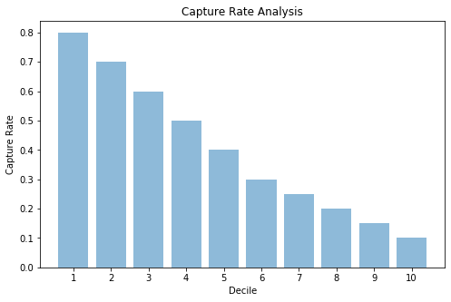

```python
import numpy as np
%matplotlib inline
import matplotlib.pyplot as plt

plt.figure(figsize=(8, 5))
y_values = df_roi['capture_rate']
y_pos = np.arange(len(y_values))
objects = [str(n+1) for n in range(10)]
#objects = df_roi['decile']*10
plt.bar(y_pos, y_values, align='center', alpha=0.5)
plt.xticks(y_pos, objects)
plt.ylabel('Capture Rate')
plt.xlabel('Decile')
#plt.xlabel('Percentage of sample')
plt.title('Capture Rate Analysis')
plt.show()
```

## Cumulative gains chart

The cumulative gains chart shows the gain you would achieve by using the model to target or take an action versus randomly targeting.  
For example: In predictive maintenance scenario (where the model typically predicts the likelihood of a machine to fail) if you randomly sample 20% of your machines due for scheduled service maintenance, you can expect to find only 20% of your machines that were going to fail (this would be your baseline). However, if you target 20% of your machines and if the model can ensure that 60% of the machines that are going to fail are in this group, then that would be the gain from your model.  
In the cumulative gains chart, X axis is the percentage of population sampled and the Y axis is the proportion of actual failures in the sample. The curve shows the percentage of the overall number of cases "gained" by targeting a given percentage of the total number of cases. The farther above the baseline a curve lies, the greater the gain.

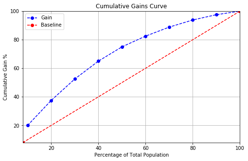

```python
plt.figure(figsize=(8, 5))
plt.plot(df_roi['decile']*10, df_roi['cum_gain']*100, linestyle='--', marker='o', color='b',label='Gain')
plt.ylim((8,100))
plt.xlim((8,100))
x_low, x_high = plt.xlim()
y_low, y_high = plt.ylim()
low = max(x_low, y_low)
high = min(x_high, y_high)
diag_line = [low, high]
plt.plot(diag_line,diag_line, marker='o',linestyle='--',color='r',label='Baseline')
plt.title('Cumulative Gains Curve')
plt.ylabel('Cumulative Gain %')
plt.xlabel('Percentage of Total Population')
plt.legend(loc='upper left')
plt.grid(True)
```

In the gain chart above, we can see that by targeting 50% of the population using the predicted probabilities from the model we would gain 75% of the events. By targeting 40% of the population using the predictions from the model we would gain only 65% of the events whereas by targeting 60% of the population we would gain 82% of the events.

If the business objective or KPI could be met by say 65% of events gained, we could use this to set the threshold for the classifier by mapping that desired percentage to the appropriate cutoff value. The threshold determines how to label the predicted probabilities as positive or negative

## Lift chart

The lift chart is derived from the cumulative gains chart. In the lift chart, X axis is the percentage of population sampled and the Y axis is the ratio between the results obtained with and without the predictive model. This is nothing but the ratio of the cumulative gain to the baseline from the cumulative gains plot. The lift curve is another measure of the effectiveness of a predictive model in getting a relatively large portion of positives by selecting a relatively small number of cases or in other words, how effectively we can skim the cream.

For example: In healthcare, a common scenario is to outreach to at risk patients for preemptive intervention. This could be for intervention for diabetes or hypertension or any other condition. There is always the need to optimize outreach programs due to limited resources to reach a large portion of truly at-risk patient population while minimizing the number of outreaches.

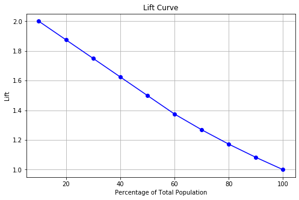

```python
plt.figure(figsize=(8, 5))
plt.plot( df_roi['decile']*10, df_roi['lift'], linestyle='-', marker='o', color='b')
plt.title('Lift Curve')
plt.ylabel('Lift')
#plt.xlabel('Percentage of sample')
plt.xlabel('Percentage of Total Population')
plt.grid(True)
```

In the lift curve above as you will notice, the lift will vary with the sample of population we choose to target. A high lift when targeting only a small sample of population (instances with high predicted probabilities) is a tell-tale sign of a good classifier. Lift will continue to decrease as we increasingly target larger sample of population.

In this post we used python to compute some business metrics for a classifier. Hopefully with the help of these metrics you will be able to establish the ROI for your Machine Learning model which will enable adoption of the model for business operations. Enjoy!

@Shaheen_Gauher, PhD  
Director, Data Science and AI at Anthem Inc.